# Práctica Validez

Héctor Nájera

14/11/2024

# Validez

En esta práctica nos concentraremos en el escrutinio en **R** de distintos tipos de validez como: de criterio y constructo.

Recordemos que sin confiabilidad no tiene mucho sentido hablar de validez y que para llegar a esta etapa debemos estar seguros de que la confiabilidad de los puntajes/scores se sostiene.

## Validez de criterio

Usaremos los datos `"Rel_MD_data_1_1.dat"`. Estos datos contienen 11 indicadores binarios sobre un índice de privación material. Además, contiene algunas variables auxiliares que serán útiles para la validación de criterio.

Los datos los guardaremos en el objeto `D`. Asignamos etiquetas a las variables con `colnames` y dividimos entre 100 la variable `resources` para que tenga más sentido la interpretación.

```r
D<-read.table("Rel_MD_data_1_1.dat")
colnames(D)<-c("x1","x2","x3","x4","x5","x6",
                      "x7","x8","x9","x10","x11",
                      "resources","educ_yr","occupation",
                      "hh_members","class")
D$resources<-D$resources/100
D$ds<-rowSums(D[,c(1:9)])
```

### Validez de criterio: A la antigua

La validez de criterio o predictiva parte de la hipótesis de que hay una relación entre nuestro constructo y sus consecuencias/causas.

Una de las formas antiguas (aunque aún utilizadas) de validación consiste en validar los indicadores y no el constructo.

En este caso, esperaríamos una relación entre la probabilidad de tener privación y tener cierto nivel de recursos. ¿Qué tipo de relación esperaríamos?

¿Qué tipo de análisis tendríamos que hacer?

#### Correlación y Regresión

En el tipo de análisis más básico (pero necesario) esperaríamos cierta relación entre tener privación (0=Sin privación; 1=Con privación) y los años de escolaridad.

```r
cor(D$x1,D$educ_yr, method="spearman")
```

```
## [1] -0.2652751
```

La correlación es útil pero siempre es mucho más ilustrativa una gráfica. Podemos hacer una gráfica de cajas con la función `boxplot` (pro tip: Usen ggplot2 siempre). En este caso boxplot recodifica las variables! Cuidado!

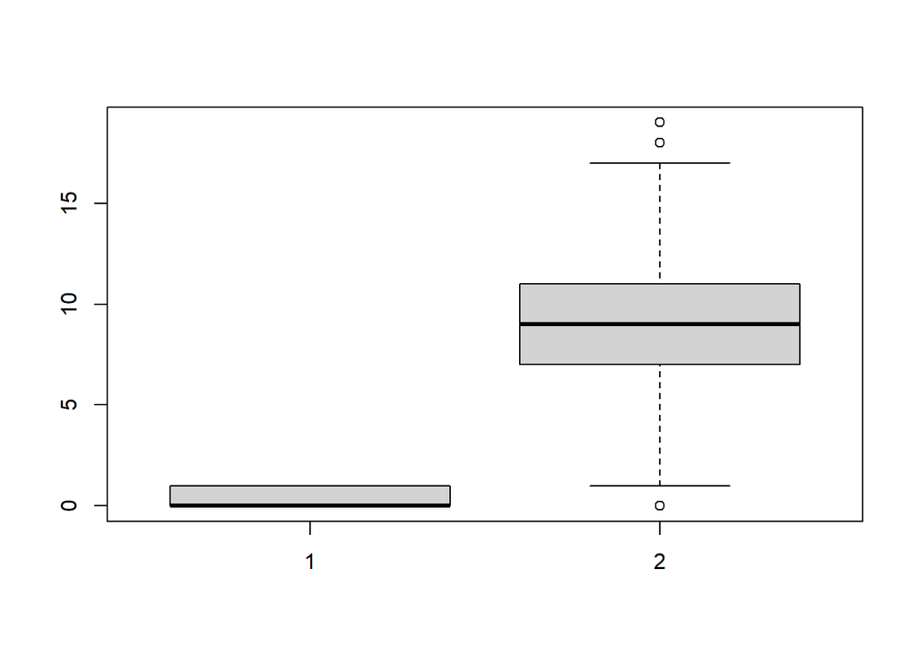

```r
boxplot(D$x1,D$educ_yr)
```

OK la relación es la esperada pero lo que idealmente buscamos es la relación ajustada (considerando ciertos controles). Como la variable dependiente es binaria tenemos que usar la función `glm`. Aquí usamos `poisson` con `log` link para obtener riesgos relativos y no odds ratios (Podrían usar `binomial(link = "logit")` para obtener odds ratios. Recuerden sus cursos de regresión es una cuestión de usar el denominador con más sentido.

```r
summary(glm(x1 ~ resources +  hh_members + educ_yr, data=D, family=poisson(link="log")))
```

```
##
## Call:
## glm(formula = x1 ~ resources + hh_members + educ_yr, family = poisson(link = "log"),
##     data = D)
##
## Coefficients:
##               Estimate Std. Error z value Pr(>|z|)
## (Intercept)  0.4583370  0.0962278   4.763 1.91e-06 ***
## resources   -0.0229071  0.0013474 -17.001  < 2e-16 ***
## hh_members   0.0002192  0.0112127   0.020    0.984
## educ_yr     -0.0360538  0.0090639  -3.978 6.96e-05 ***
## ---
## Signif. codes:  0 '***' 0.001 '**' 0.01 '*' 0.05 '.' 0.1 ' ' 1
##
## (Dispersion parameter for poisson family taken to be 1)
##
##     Null deviance: 3479.6  on 4999  degrees of freedom
## Residual deviance: 2985.8  on 4996  degrees of freedom
## AIC: 7947.8
##
## Number of Fisher Scoring iterations: 5
```

Lo que tendríamos que hacer es una regresión donde los recursos predicen la probabilidad de privación para cada uno de los indicadores. Sin embargo, tenemos **11** indicadores, o sea **11** regresiones. Además, la variable dependiente es categórica por lo que no haremos una regresión lineal sino con distribución *poisson* (puede ser logit o probit, también). Para estimar los modelos usamos la función `glm()` (Generalized Linear Model). Lo que haremos es crear una función llamada `lms` que va a iterar el mismo modelo para las **11** variables independientes, va a extraer las razones de riesgo y los intervalos de confianza. Todo lo guardaremos en la lista `coefs`.

```r
lms<-function(index)
{
  fit<-glm(D[,index] ~ D$resources +
                              D$hh_members,
           family=poisson(link="log"))
  exp(cbind(OR = coef(fit), confint(fit)))
}

coefs<-lapply(1:11,lms)
```

Por ejemplo, veamos que pasa para el primer indicador:

```r
coefs[[1]]
```

```
##                     OR     2.5 %    97.5 %
## (Intercept)  1.1997259 1.0499688 1.3690660
## D$resources  0.9754994 0.9730889 0.9778922
## D$hh_members 1.0117961 0.9904535 1.0334901
```

```r
coefs[[2]]
```

```
##                     OR     2.5 %    97.5 %
## (Intercept)  0.9893404 0.8343711 1.1705723
## D$resources  0.9660908 0.9627865 0.9693614
## D$hh_members 1.0071640 0.9799303 1.0349766
```

Si queremos ver todos con intervalos de confianza al 95%, entonces necesitamos crear una tabla. Usaremos `lapply()` para extraer de los **11** objetos en la lista los coeficientes.

```r
coefs<-lapply(coefs, function(x) unlist(x[2,]))
coefs<- as.matrix(matrix(unlist(coefs), nrow=length(coefs), byrow=T))
coefs<-data.frame(rbind(coefs[,c(1,2,3)]))

coefs$item <- rep(c("x1","x2","x3","x4","x5","x6",
                      "x7","x8","x9","x10","x11"),1)
coefs$var<-c(rep("Resources (*100)", 11))
coefs[,1:4]
```

[output not shown]

También podemos graficarlos usando `ggplot()`. Podemos ver que no hay evidencia de que los indicadores x10 y x11 estén asociados con recursos.

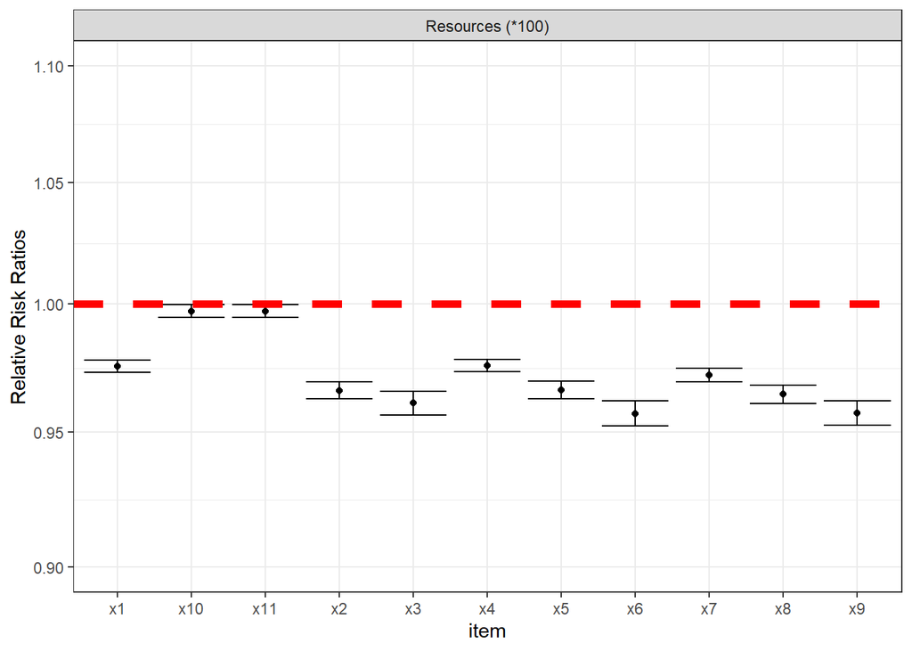

This plot shows the Relative Risk Ratios for the resources variable, adjusted by the household size. Having more resources reduces the risk of being deprived of the item x, as expected.

```r
p<- ggplot(coefs, aes(x=item,y=X1)) + geom_point() +
  geom_errorbar(aes(ymin=X2, ymax=X3)) +
 theme_bw() + scale_y_continuous(trans = 'log10', limits = c(.9, 1.1))
p + facet_grid(. ~ var) + labs(y="Relative Risk Ratios") + geom_hline(yintercept=1, linetype="dashed",
                color = "red", size=2)
```

### Grados de libertad

En el caso anterior hice un análisis de variable por variable, pero que pasa si lo hago de otra manera?

```r
fit<-glm(D$resources ~ D$x1 + D$x2 + D$x3 + D$x4 + D$x5 + D$x6 + D$x7 + D$x8 + D$x9 + D$x10 + D$x11 + D$hh_members, family="gaussian")
summary(fit)
```

```
##
## Call:
## glm(formula = D$resources ~ D$x1 + D$x2 + D$x3 + D$x4 + D$x5 +
##     D$x6 + D$x7 + D$x8 + D$x9 + D$x10 + D$x11 + D$hh_members,
##     family = "gaussian")
##
## Coefficients:
##              Estimate Std. Error t value Pr(>|t|)
## (Intercept)  60.55760    0.56513 107.157  < 2e-16 ***
## D$x1         -6.37741    0.58526 -10.897  < 2e-16 ***
## D$x2         -3.17902    0.65648  -4.843 1.32e-06 ***
## D$x3          0.03629    0.74757   0.049  0.96129
## D$x4         -5.75680    0.59245  -9.717  < 2e-16 ***
## D$x5         -1.91024    0.67737  -2.820  0.00482 **
## D$x6         -1.97922    0.75713  -2.614  0.00897 **
## D$x7         -6.94055    0.60609 -11.451  < 2e-16 ***
## D$x8         -1.07670    0.71383  -1.508  0.13153
## D$x9         -1.48226    0.78486  -1.889  0.05901 .
## D$x10        -0.19022    0.48307  -0.394  0.69377
## D$x11        -0.07778    0.48219  -0.161  0.87186
## D$hh_members -2.12654    0.12637 -16.828  < 2e-16 ***
## ---
## Signif. codes:  0 '***' 0.001 '**' 0.01 '*' 0.05 '.' 0.1 ' ' 1
##
## (Dispersion parameter for gaussian family taken to be 258.1739)
##
##     Null deviance: 1910337  on 4999  degrees of freedom
## Residual deviance: 1287513  on 4987  degrees of freedom
## AIC: 41973
##
## Number of Fisher Scoring iterations: 2
```

```r
xnam <- paste("x", 1:11, sep="")
summary(glm(as.formula(paste("resources ~ ", paste(xnam, collapse= "+"), "+  hh_members")) , data=D))
```

```
##
## Call:
## glm(formula = as.formula(paste("resources ~ ", paste(xnam, collapse = "+"),
##     "+  hh_members")), data = D)
##
## Coefficients:
##             Estimate Std. Error t value Pr(>|t|)
## (Intercept) 60.55760    0.56513 107.157  < 2e-16 ***
## x1          -6.37741    0.58526 -10.897  < 2e-16 ***
## x2          -3.17902    0.65648  -4.843 1.32e-06 ***
## x3           0.03629    0.74757   0.049  0.96129
## x4          -5.75680    0.59245  -9.717  < 2e-16 ***
## x5          -1.91024    0.67737  -2.820  0.00482 **
## x6          -1.97922    0.75713  -2.614  0.00897 **
## x7          -6.94055    0.60609 -11.451  < 2e-16 ***
## x8          -1.07670    0.71383  -1.508  0.13153
## x9          -1.48226    0.78486  -1.889  0.05901 .
## x10         -0.19022    0.48307  -0.394  0.69377
## x11         -0.07778    0.48219  -0.161  0.87186
## hh_members  -2.12654    0.12637 -16.828  < 2e-16 ***
## ---
## Signif. codes:  0 '***' 0.001 '**' 0.01 '*' 0.05 '.' 0.1 ' ' 1
##
## (Dispersion parameter for gaussian family taken to be 258.1739)
##
##     Null deviance: 1910337  on 4999  degrees of freedom
## Residual deviance: 1287513  on 4987  degrees of freedom
## AIC: 41973
##
## Number of Fisher Scoring iterations: 2
```

```r
cor(D[,1:11])
```

```
##             x1         x2         x3         x4         x5           x6
## x1  1.00000000 0.54173405 0.40820974 0.41952463 0.37238286  0.285312384
## x2  0.54173405 1.00000000 0.51389952 0.36777004 0.35459827  0.303116990
## x3  0.40820974 0.51389952 1.00000000 0.30175292 0.32544582  0.303677953
## x4  0.41952463 0.36777004 0.30175292 1.00000000 0.56717349  0.410067411
## x5  0.37238286 0.35459827 0.32544582 0.56717349 1.00000000  0.524079821
## x6  0.28531238 0.30311699 0.30367795 0.41006741 0.52407982  1.000000000
## x7  0.42879374 0.37266102 0.32232521 0.43070308 0.38706736  0.308838895
## x8  0.37001601 0.36369063 0.31797416 0.34636472 0.36663433  0.312669861
## x9  0.29590085 0.31932145 0.30407769 0.29752119 0.33437350  0.287869854
## x10 0.07092112 0.04123715 0.05371662 0.04024621 0.03491891  0.038653995
## x11 0.06650315 0.07493510 0.06807629 0.06321469 0.02893780 -0.003257098
##             x7         x8         x9        x10          x11
## x1  0.42879374 0.37001601 0.29590085 0.07092112  0.066503145
## x2  0.37266102 0.36369063 0.31932145 0.04123715  0.074935099
## x3  0.32232521 0.31797416 0.30407769 0.05371662  0.068076290
## x4  0.43070308 0.34636472 0.29752119 0.04024621  0.063214687
## x5  0.38706736 0.36663433 0.33437350 0.03491891  0.028937796
## x6  0.30883889 0.31266986 0.28786985 0.03865399 -0.003257098
## x7  1.00000000 0.57264623 0.44760506 0.03026770  0.048409010
## x8  0.57264623 1.00000000 0.56747965 0.03274826  0.023710075
## x9  0.44760506 0.56747965 1.00000000 0.04372168  0.027268567
## x10 0.03026770 0.03274826 0.04372168 1.00000000  0.037610388
## x11 0.04840901 0.02371007 0.02726857 0.03761039  1.000000000
```

```r
fit<-glm(log(D$resources) ~ D$x1 + D$x3 + D$x4 + D$x5 + D$x6 + D$x7 + D$x8 + D$x9 + D$x10 + D$x11 + D$hh_members, family="gaussian")
summary(fit)
```

```
##
## Call:
## glm(formula = log(D$resources) ~ D$x1 + D$x3 + D$x4 + D$x5 +
##     D$x6 + D$x7 + D$x8 + D$x9 + D$x10 + D$x11 + D$hh_members,
##     family = "gaussian")
##
## Coefficients:
##                Estimate Std. Error t value Pr(>|t|)
## (Intercept)   4.0652692  0.0157030 258.885  < 2e-16 ***
## D$x1         -0.1715964  0.0153573 -11.174  < 2e-16 ***
## D$x3         -0.0425167  0.0196570  -2.163 0.030594 *
## D$x4         -0.1293645  0.0164359  -7.871 4.29e-15 ***
## D$x5         -0.0679863  0.0188059  -3.615 0.000303 ***
## D$x6         -0.0865241  0.0210155  -4.117 3.90e-05 ***
## D$x7         -0.1634197  0.0168280  -9.711  < 2e-16 ***
## D$x8         -0.0554343  0.0197935  -2.801 0.005120 **
## D$x9         -0.0714697  0.0217778  -3.282 0.001039 **
## D$x10         0.0008438  0.0134197   0.063 0.949864
## D$x11        -0.0037710  0.0133892  -0.282 0.778225
## D$hh_members -0.0484988  0.0035119 -13.810  < 2e-16 ***
## ---
## Signif. codes:  0 '***' 0.001 '**' 0.01 '*' 0.05 '.' 0.1 ' ' 1
##
## (Dispersion parameter for gaussian family taken to be 0.1991325)
##
##     Null deviance: 1394.33  on 4996  degrees of freedom
## Residual deviance:  992.68  on 4985  degrees of freedom
##   (3 observations deleted due to missingness)
## AIC: 6130.8
##
## Number of Fisher Scoring iterations: 2
```

### ¿Qué pasa cuando no tengo una variable que fue explícitamente construida para validar?

Tendríamos que usar alguna variable auxiliar. En este caso ocupación o educación. El ejercicio es muy similar al anterior, pero usamos otros predictores.

```r
lms<-function(index)
{
  fit<-glm(D[,index] ~ D$occupation +
                              D$educ_yr +
                              D$hh_members,
           family=poisson(link="log"))
  exp(cbind(OR = coef(fit), confint(fit)))
}

coefs<-lapply(1:11,lms)

coefs[[1]]
```

```
##                     OR     2.5 %    97.5 %
## (Intercept)  0.6866791 0.5503763 0.8554189
## D$occupation 1.0531859 1.0377362 1.0688189
## D$educ_yr    0.9206710 0.9051449 0.9364577
## D$hh_members 1.0163837 0.9939741 1.0391996
```

Tenemos que hace una serie de manipulaciones para poder leer los coeficientes de los 11 modelos. Esto fundamentalmente implica:

1 Extraer los coeficientes de cada modelo con `lapply` (Aplicar la misma función a una lista de objetos.)

2 Juntarlos en un mismo objeto

3 Asignar etiquetas

```r
coefs<-lapply(coefs, function(x) unlist(x[2:3,]))
coefs<- as.matrix(matrix(unlist(coefs), nrow=length(coefs), byrow=T))
coefs<-data.frame(rbind(coefs[,c(1,3,5)],coefs[,c(2,4,6)]))

coefs$item <- rep(c("x1","x2","x3","x4","x5","x6",
                      "x7","x8","x9","x10","x11"),2)
coefs$var<-c(rep("Occupation (Skill) scale", 11), rep("Education years", 11))
coefs
```

```
##           X1        X2        X3 item                      var
## 1  1.0531859 1.0377362 1.0688189   x1 Occupation (Skill) scale
## 2  1.0691741 1.0489816 1.0896804   x2 Occupation (Skill) scale
## 3  1.0781765 1.0510322 1.1058950   x3 Occupation (Skill) scale
## 4  1.0590273 1.0433546 1.0748872   x4 Occupation (Skill) scale
## 5  1.0721107 1.0517452 1.0927967   x5 Occupation (Skill) scale
## 6  1.0993761 1.0713526 1.1280058   x6 Occupation (Skill) scale
## 7  1.0610757 1.0448192 1.0775352   x7 Occupation (Skill) scale
## 8  1.0728834 1.0512460 1.0948827   x8 Occupation (Skill) scale
## 9  1.1084601 1.0802115 1.1373136   x9 Occupation (Skill) scale
## 10 1.0001156 0.9817638 1.0187286  x10 Occupation (Skill) scale
## 11 1.0087886 0.9905182 1.0273171  x11 Occupation (Skill) scale
## 12 0.9206710 0.9051449 0.9364577   x1          Education years
## 13 0.8977545 0.8780443 0.9178932   x2          Education years
## 14 0.8758993 0.8500184 0.9025356   x3          Education years
## 15 0.9311522 0.9153057 0.9472680   x4          Education years
## 16 0.9052537 0.8851807 0.9257679   x5          Education years
## 17 0.8979686 0.8708921 0.9258545   x6          Education years
## 18 0.9150086 0.8987985 0.9315038   x7          Education years
## 19 0.9029371 0.8816859 0.9246844   x8          Education years
## 20 0.8974289 0.8704803 0.9251801   x9          Education years
## 21 0.9848866 0.9650072 1.0051781  x10          Education years
## 22 0.9958716 0.9759022 1.0162522  x11          Education years
```

Y podemos graficarlos de la siguiente manera:

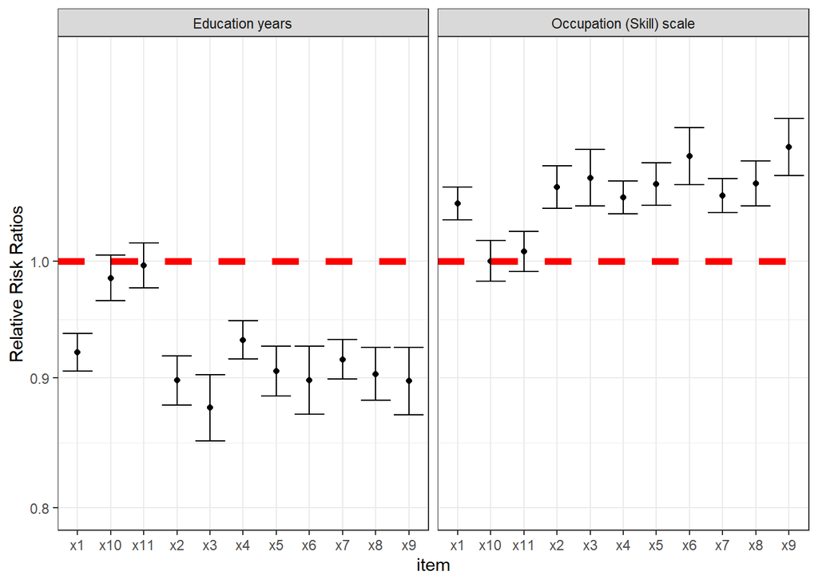

This plot shows the Relative Risk Ratios for each item using two validators (adjusted by the total household members)

```r
p<- ggplot(coefs, aes(x=item,y=X1)) + geom_point() +
  geom_errorbar(aes(ymin=X2, ymax=X3)) +
 theme_bw() + scale_y_continuous(trans = 'log10', limits = c(.8, 1.2))
p + facet_grid(. ~ var) + labs(y="Relative Risk Ratios") + geom_hline(yintercept=1, linetype="dashed",
                color = "red", size=2)
```

## Validez de Constructo

La validez de constructo se enfoca en si el modelo global se sostiene, i.e. que efectivamente en los datos parece haber las dimensiones que se piensan existen por teoría. En este caso se parte de que hay tres dimensiones y un factor de alto orden. Con tres indicadores por dimensión. Estimamos el modelo con la función `sem()` en lavaan.

```r
MD_model <- ' f1  =~ x1 + x2 + x3
              f2 =~ x4 + x5 + x6
              f3   =~ x7 + x8 + x9
               h =~ f1 + f2 + f3
'

fit <- sem(MD_model,
           data = D,ordered=c("x1","x2","x3","x4","x5",
                                     "x6","x7","x8","x9"))
```

Además de inspeccionar las cargas factoriales, en la validez de constructo lo que importa es si globalmente nuestro modelo ajusta a los datos. Para ello usamos los estadísticos tli, cfi, rmsea y chisq. Observamos que en todos los casos el ajuste del modelo es muy bueno.

```r
chisq<-fitmeasures(fit,fit.measures = c("chisq","df","pvalue"))
relfit<-fitmeasures(fit,fit.measures = c("tli","cfi"))
rmsea<-fitmeasures(fit,fit.measures = c("rmsea", "rmsea.ci.lower",
                                        "rmsea.ci.upper", "rmsea.pvalue"))
chisq
```

```
##  chisq     df pvalue
## 17.717 24.000  0.817
```

```r
relfit
```

```
## tli cfi
##   1   1
```

```r
rmsea
```

```
##          rmsea rmsea.ci.lower rmsea.ci.upper   rmsea.pvalue
##          0.000          0.000          0.007          1.000
```

```r
library(lavaanExtra)
```

```r
nice_lavaanPlot(fit, sig=1, graph_options = list(rankdir="LR", overlap="false"),  edge_options = list(color = "red"))
```

[interactive chart not shown]

# Segunda parte

## Validez de concurrente, constructo y de criterio con SEM

¡Gracias a 100 años de métodos para variables latentes tenemos SEM!

Ahora podemos hacer este tipo de análisis en un paso. Veamos cómo luce el modelo.

## Validez concurrente

Supongamos que el modelo de medición propone que hay tres medidciones alternativas y estas deberían concurrir. Esto significaría que los factores deberían están correlacionados.

```r
MD_model <- ' f1  =~ x1 + x2 + x3
              f2 =~ x4 + x5 + x6
              f3   =~ x7 + x8 + x9'

fit <- sem(MD_model,
           data = D,ordered=c("x1","x2","x3","x4","x5",
                                     "x6","x7","x8","x9"))
summary(fit, standardized=TRUE, rsquare=TRUE)
```

```
## lavaan 0.6-19 ended normally after 25 iterations
##
##   Estimator                                       DWLS
##   Optimization method                           NLMINB
##   Number of model parameters                        21
##
##   Number of observations                          5000
##
## Model Test User Model:
##                                               Standard      Scaled
##   Test Statistic                                17.717      30.864
##   Degrees of freedom                                24          24
##   P-value (Chi-square)                           0.817       0.158
##   Scaling correction factor                                  0.623
##   Shift parameter                                            2.435
##     simple second-order correction
##
## Parameter Estimates:
##
##   Parameterization                               Delta
##   Standard errors                           Robust.sem
##   Information                                 Expected
##   Information saturated (h1) model        Unstructured
##
## Latent Variables:
##                    Estimate  Std.Err  z-value  P(>|z|)   Std.lv  Std.all
##   f1 =~
##     x1                1.000                               0.924    0.924
##     x2                0.962    0.016   59.881    0.000    0.888    0.888
##     x3                0.945    0.017   54.574    0.000    0.873    0.873
##   f2 =~
##     x4                1.000                               0.929    0.929
##     x5                0.987    0.015   63.819    0.000    0.917    0.917
##     x6                0.932    0.016   56.743    0.000    0.866    0.866
##   f3 =~
##     x7                1.000                               0.947    0.947
##     x8                0.967    0.014   67.012    0.000    0.916    0.916
##     x9                0.944    0.015   63.801    0.000    0.894    0.894
##
## Covariances:
```

[output cut: 30 more lines]

```
##     f1                0.854    0.018   46.585    0.000    1.000    1.000
##     f2                0.863    0.017   49.718    0.000    1.000    1.000
##     f3                0.897    0.017   53.118    0.000    1.000    1.000
##
## R-Square:
##                    Estimate
##     x1                0.854
##     x2                0.789
##     x3                0.762
##     x4                0.863
##     x5                0.841
##     x6                0.749
##     x7                0.897
##     x8                0.839
##     x9                0.800
```

## Modelo alternativo

Otro modelo muy popular de validación es cuando se piensa que los indicadores de un índice deberían “concurrir” con otros indicadores. Por ejemplo, que otra muestra de indicadores del fenómeno de interés (x4 a x6) esté correlacionada con los indicadores observados.

Para ello basta especificar las correlaciones de la siguiente manera ¿Podría ser una regresión?

```r
MD_model <- ' f1  =~ x1 + x2 + x3
              x1 ~~ x4 + x5 + x6
              x2 ~~ x4 + x5 + x6
              x3 ~~ x4 + x5 + x6'

fit <- sem(MD_model,
           data = D,ordered=c("x1","x2","x3","x4","x5",
                                     "x6"))
summary(fit, rsquare=TRUE)
```

```
## lavaan 0.6-19 ended normally after 17 iterations
##
##   Estimator                                       DWLS
##   Optimization method                           NLMINB
##   Number of model parameters                        18
##
##   Number of observations                          5000
##
## Model Test User Model:
##                                                Standard      Scaled
##   Test Statistic                              13368.137   12575.413
##   Degrees of freedom                                  3           3
##   P-value (Chi-square)                            0.000       0.000
##   Scaling correction factor                                   1.063
##   Shift parameter                                             0.178
##     simple second-order correction
##
## Parameter Estimates:
##
##   Parameterization                               Delta
##   Standard errors                           Robust.sem
##   Information                                 Expected
##   Information saturated (h1) model        Unstructured
##
## Latent Variables:
##                    Estimate  Std.Err  z-value  P(>|z|)
##   f1 =~
##     x1                1.000
##     x2                1.001    0.022   45.076    0.000
##     x3                0.969    0.019   51.050    0.000
##
## Covariances:
##                    Estimate  Std.Err  z-value  P(>|z|)
##  .x1 ~~
##     x4                0.612    0.016   38.407    0.000
##     x5                0.591    0.018   33.626    0.000
##     x6                0.543    0.022   24.881    0.000
##  .x2 ~~
##     x4                0.580    0.018   32.747    0.000
##     x5                0.551    0.019   29.347    0.000
```

[output cut: 15 more lines]

```
## Variances:
##                    Estimate  Std.Err  z-value  P(>|z|)
##    .x1                0.183
##    .x2                0.181
##    .x3                0.233
##     x4                1.000
##     x5                1.000
##     x6                1.000
##     f1                0.817    0.022   37.510    0.000
##
## R-Square:
##                    Estimate
##     x1                0.817
##     x2                0.819
##     x3                0.767
```

## Modelo de validación completo

Bajo un modelo teórico bien especificado, debería ser posible estimar la relación del factor de interés con su posible validador. En este caso h respecto a la variable de recursos (ajustada por los miembros del hogar).

```r
MD_model <- ' f1  =~ x1 + x2 + x3
              f2 =~ x4 + x5 + x6
              f3   =~ x7 + x8 + x9
               h =~ f1 + f2 + f3
               h ~ resources + hh_members
'

fit <- sem(MD_model,
           data = D,ordered=c("x1","x2","x3","x4","x5",
                                     "x6","x7","x8","x9"))
summary(fit, rsquare=TRUE)
```

```
## lavaan 0.6-19 ended normally after 29 iterations
##
##   Estimator                                       DWLS
##   Optimization method                           NLMINB
##   Number of model parameters                        23
##
##   Number of observations                          5000
##
## Model Test User Model:
##                                               Standard      Scaled
##   Test Statistic                                26.066      38.322
##   Degrees of freedom                                40          40
##   P-value (Chi-square)                           0.956       0.546
##   Scaling correction factor                                  0.771
##   Shift parameter                                            4.523
##     simple second-order correction
##
## Parameter Estimates:
##
##   Parameterization                               Delta
##   Standard errors                           Robust.sem
##   Information                                 Expected
##   Information saturated (h1) model        Unstructured
##
## Latent Variables:
##                    Estimate  Std.Err  z-value  P(>|z|)
##   f1 =~
##     x1                1.000
##     x2                0.969    0.021   46.336    0.000
##     x3                0.956    0.022   43.417    0.000
##   f2 =~
##     x4                1.000
##     x5                0.997    0.020   48.926    0.000
##     x6                0.932    0.021   43.632    0.000
##   f3 =~
##     x7                1.000
##     x8                0.974    0.019   51.561    0.000
##     x9                0.953    0.019   49.613    0.000
##   h =~
##     f1                1.000
```

[output cut: 37 more lines]

```
## R-Square:
##                    Estimate
##     x1                0.841
##     x2                0.803
##     x3                0.786
##     x4                0.853
##     x5                0.849
##     x6                0.767
##     x7                0.885
##     x8                0.851
##     x9                0.824
##     f1                0.715
##     f2                0.696
##     f3                0.707
##     h                 0.431
```

### Graficamos el modelo anterior

```r
#lavaanPlot(model = fit, graph_options = list(layout = "twopi"), node_options = list(shape = "box", fontname = "Helvetica"), edge_options = list(color = "grey"), coefs = TRUE, covs = TRUE, stars = TRUE, digits = 1, stand = TRUE)

library(lavaanExtra)
nice_lavaanPlot(fit, sig=1, graph_options = list(rankdir="LR", overlap="false"),  edge_options = list(color = "red"))
```

[interactive chart not shown]

Ahora examinamos el ajuste global. ¿Es necesario un buen ajuste global? Depende de la hipótesis.

```r
chisq<-fitmeasures(fit,fit.measures = c("chisq","df","pvalue"))
relfit<-fitmeasures(fit,fit.measures = c("tli","cfi"))
rmsea<-fitmeasures(fit,fit.measures = c("rmsea", "rmsea.ci.lower",
                                        "rmsea.ci.upper", "rmsea.pvalue"))
chisq
```

```
##  chisq     df pvalue
## 26.066 40.000  0.956
```

```r
relfit
```

```
## tli cfi
##   1   1
```

```r
rmsea
```

```
##          rmsea rmsea.ci.lower rmsea.ci.upper   rmsea.pvalue
##              0              0              0              1
```

El parámetro decisivo en la validez de criterio es la pendiente de la relación entre recursos y el factor. Veamos qué resultado obtuvimos.

Noten que otra hipótesis sería sobre la magnitud del parámetro (**¿Bayes?**)

```r
slope<-as.data.frame(parameterEstimates(fit))
slope[13,]
```

```
##    lhs op       rhs         est           se        z pvalue    ci.lower
## 13   h  ~ resources -0.02989634 0.0009216571 -32.4376      0 -0.03170276
##       ci.upper
## 13 -0.02808993
```

# Alternativa con regresiones específicas por indicador en el contexto del modelo latente

SEM es lo suficientemente flexible para poder estimar regresiones condicionadas en el modelo estimado. Por ejemplo, la relación de cada indicador con sus validadores:

```r
MD_model <- ' f1  =~ x1 + x2 + x3
              f2 =~ x4 + x5 + x6
              f3   =~ x7 + x8 + x9
               h =~ f1 + f2 + f3
               x1 ~ resources + hh_members
               x2 ~ resources + hh_members
               x3 ~ resources + hh_members
               x4 ~ resources + hh_members
               x5 ~ resources + hh_members
               x6 ~ resources + hh_members
               x7 ~ resources + hh_members
               x8 ~ resources + hh_members
               x9 ~ resources + hh_members
'

fit2 <- sem(MD_model,
           data = D,ordered=c("x1","x2","x3","x4","x5",
                                     "x6","x7","x8","x9"))
 summary(fit2)
```

```
## lavaan 0.6-19 ended normally after 71 iterations
##
##   Estimator                                       DWLS
##   Optimization method                           NLMINB
##   Number of model parameters                        39
##
##   Number of observations                          5000
##
## Model Test User Model:
##                                               Standard      Scaled
##   Test Statistic                                11.646      19.643
##   Degrees of freedom                                24          24
##   P-value (Chi-square)                           0.984       0.717
##   Scaling correction factor                                  0.674
##   Shift parameter                                            2.376
##     simple second-order correction
##
## Parameter Estimates:
##
##   Parameterization                               Delta
##   Standard errors                           Robust.sem
##   Information                                 Expected
##   Information saturated (h1) model        Unstructured
##
## Latent Variables:
##                    Estimate  Std.Err  z-value  P(>|z|)
##   f1 =~
##     x1                1.000
##     x2                0.968    0.023   41.571    0.000
##     x3                0.965    0.024   39.656    0.000
##   f2 =~
##     x4                1.000
##     x5                0.999    0.023   43.905    0.000
##     x6                0.927    0.023   41.041    0.000
##   f3 =~
##     x7                1.000
##     x8                0.984    0.021   46.865    0.000
##     x9                0.959    0.020   46.817    0.000
##   h =~
##     f1                1.000
```

[output cut: 45 more lines]

```
## Variances:
##                    Estimate  Std.Err  z-value  P(>|z|)
##    .x1                0.218
##    .x2                0.267
##    .x3                0.272
##    .x4                0.197
##    .x5                0.199
##    .x6                0.309
##    .x7                0.167
##    .x8                0.193
##    .x9                0.234
##    .f1                0.318    0.025   12.622    0.000
##    .f2                0.350    0.025   13.922    0.000
##    .f3                0.354    0.026   13.655    0.000
##     h                 0.463    0.025   18.557    0.000
```

## Sobre-ajuste a los datos

```r
nice_lavaanPlot(fit2, sig=1, graph_options = list(rankdir="LR", overlap="false"),  edge_options = list(color = "red"))
```

[interactive chart not shown]

```r
#lavaanPlot(model = fit2, graph_options = list(layout = "neato",  overlap="false"), node_options = list(shape = "box", fontname = "Helvetica"), edge_options = list(color = "grey"), coefs = TRUE, covs = TRUE, stars = TRUE,  stand = TRUE)
```

## Validez de criterio con SEM

Ahora lo que hacemos es hacer regresiones para cada uno de los indicadores binarios. `lavaan` reconocerá que estos indicadores observados son de tal tipo al utilizar la instrucción `ordered`.

```r
MD_model <- '  x1 ~ occupation + educ_yr + hh_members
               x2 ~ occupation + educ_yr + hh_members
               x3 ~ occupation + educ_yr + hh_members
               x4 ~ occupation + educ_yr + hh_members
               x5 ~ occupation + educ_yr + hh_members
               x6 ~ occupation + educ_yr + hh_members
               x7 ~ occupation + educ_yr + hh_members
               x8 ~ occupation + educ_yr + hh_members
               x9 ~ occupation + educ_yr + hh_members
               x10 ~ occupation + educ_yr + hh_members
               x11 ~ occupation + educ_yr + hh_members
'

fit2 <- sem(MD_model,
           data = D,ordered=c("x1","x2","x3","x4","x5",
                                     "x6","x7","x8","x9","x10","x11"))
 summary(fit2)
```

```
## lavaan 0.6-19 ended normally after 39 iterations
##
##   Estimator                                       DWLS
##   Optimization method                           NLMINB
##   Number of model parameters                        99
##
##   Number of observations                          5000
##
## Model Test User Model:
##                                               Standard      Scaled
##   Test Statistic                                 0.000       0.000
##   Degrees of freedom                                 0           0
##
## Parameter Estimates:
##
##   Parameterization                               Delta
##   Standard errors                           Robust.sem
##   Information                                 Expected
##   Information saturated (h1) model        Unstructured
##
## Regressions:
##                    Estimate  Std.Err  z-value  P(>|z|)
##   x1 ~
##     occupation        0.070    0.007    9.937    0.000
##     educ_yr          -0.105    0.008  -13.183    0.000
##     hh_members        0.021    0.011    1.982    0.047
##   x2 ~
##     occupation        0.061    0.007    8.533    0.000
##     educ_yr          -0.095    0.008  -11.385    0.000
##     hh_members        0.011    0.011    0.971    0.332
##   x3 ~
##     occupation        0.054    0.008    6.588    0.000
##     educ_yr          -0.090    0.009   -9.714    0.000
##     hh_members        0.016    0.012    1.319    0.187
##   x4 ~
##     occupation        0.076    0.007   10.849    0.000
##     educ_yr          -0.088    0.008  -11.308    0.000
##     hh_members        0.022    0.011    2.114    0.034
##   x5 ~
##     occupation        0.063    0.007    8.746    0.000
```

[output cut: 107 more lines]

```
##     x11|t1            0.514    0.106    4.842    0.000
##
## Variances:
##                    Estimate  Std.Err  z-value  P(>|z|)
##    .x1                1.000
##    .x2                1.000
##    .x3                1.000
##    .x4                1.000
##    .x5                1.000
##    .x6                1.000
##    .x7                1.000
##    .x8                1.000
##    .x9                1.000
##    .x10               1.000
##    .x11               1.000
```

El modelo de SEM es equivalente bajo un modelo probit.

```r
lms<-function(index)
{
  fit<-glm(D[,index] ~ D$occupation +
                              D$educ_yr +
                              D$hh_members,
           family=binomial(link="probit"))
}

coefs<-lapply(1:11,lms)

coefs[[1]]
```

```
##
## Call:  glm(formula = D[, index] ~ D$occupation + D$educ_yr + D$hh_members,
##     family = binomial(link = "probit"))
##
## Coefficients:
##  (Intercept)  D$occupation     D$educ_yr  D$hh_members
##      0.43242       0.06998      -0.10471       0.02122
##
## Degrees of Freedom: 4999 Total (i.e. Null);  4996 Residual
## Null Deviance:       6931
## Residual Deviance: 6458  AIC: 6466
```